# Threshold of Risk Inference: Examples with Simulated Data

# Time to Event Data

Now, let’s consider the scenario where inference on risk thresholds is done with time to event data (as described in Section 4 of the paper). Let time $t_0$ denote end of follow-up ($t_0>0$), $T$ denote survival time, $S$ denote immune response, $C$ denote censoring status ($C=1$ denoting right censoring at or before time $t_0$, and $C=0$ denoting observed disease before time $t_0$). Suppose $S$ is observed for proportion $p_0$ of subjects with $C=1$ and proportion $p_1$ of subjects with $C=0$. In the following simulated examples, sample size $n=12,500$ where $S$ is generated from a gamma distribution with mean and variance 4 and $T|S$ is generated by log$(T)=\beta_0+\beta_1S+\epsilon$ where $\epsilon$ is generated from a logistic distribution. The slope $\beta_1$ sas set to 2 and $\beta_0$ was determined based on the chosen disease risk $\Pr(T<t_0)$; in the following simulations risks of 0.01 and 0.1 were used with $p_0=0.2$ and $p_1=1$. The R function sim_data_logistic found in the GitHub repository simulates data under this model (based on choosen values of $n, \beta_1, t_0$, $p_0$, $p_1$, and disease risk).

For disease risk 0.01, point estimates and 95$\%$ confidence intervals are computed of thresholds for risk levels 0.001, 0.003, 0.005, 0.007, and 0.009 and for disease risk 0.1, point estimates and 95$\%$ confidence intervals are computed of thresholds for risk levels 0.009, 0.01, 0.03, 0.05, 0.07, and 0.09. The confidence intervals are computed using 2000 bootstrap resamples. These calculations were done using the R function Thres_Surv, whose source code can be found in the GitHub repository, which implements the methods detailed for Section 4 for inference with time to event data. These estimates and confidence intervals were computed using $\hat{v}_c^{w}$ (referred to as the “naive” method in the R function Thres_Surv) and $\hat{v}_c^{wk}$ (“adjusted” method), as defined in Section 4 of the paper. For each threshold, the point estimate and confidence interval using $\hat{v}_c^{wk}$ are plotted with the corresponding risk level on x axis; the point estimate is colored red and the true threshold is colored blue.

The true thresholds under the model from which the data were simulated (models detailed previously) are also provided (function sim_data_logistic calculates these for vector of choosen risk levels).

```r
source("../sim_data_logistic.R")
source("../Thres_Surv.R")

## Low risk example
sim_data <- Sim_data_logistic(Risk = 0.01, n=12500, p=c(0.001,0.003,0.005,0.007,0.009), p0=0.2, p1=1, seed_val = 012)

vac_data_analysis_LR <- sim_data$simmed_data %>% select(S_obs, TObs, Cstatus)
low_risk_tte_results <- Thres_Surv(dataset = vac_data_analysis_LR, p=c(0.001,0.003,0.005,0.007,0.009), weighted=TRUE, bts=2000)
low_risk_tte_results
```

```
##    Risk_Level   Method  Est CI_LL CI_UL CI_Width
## 1       0.001 Adjusted 2.07  1.91  3.05     1.15
## 2       0.003 Adjusted 1.79  1.34  1.98     0.64
## 3       0.005 Adjusted 1.26  0.94  1.76     0.83
## 4       0.007 Adjusted 0.96  0.51  1.28     0.77
## 5       0.009 Adjusted 0.67  0.34  1.03     0.69
## 6       0.001    Naive 2.00  1.79  2.21     0.42
## 7       0.003    Naive 1.39  1.02  1.79     0.76
## 8       0.005    Naive 0.89  0.34  1.19     0.85
## 9       0.007    Naive 0.34  0.34  0.77     0.43
## 10      0.009    Naive 0.34  0.34  0.46     0.12
```

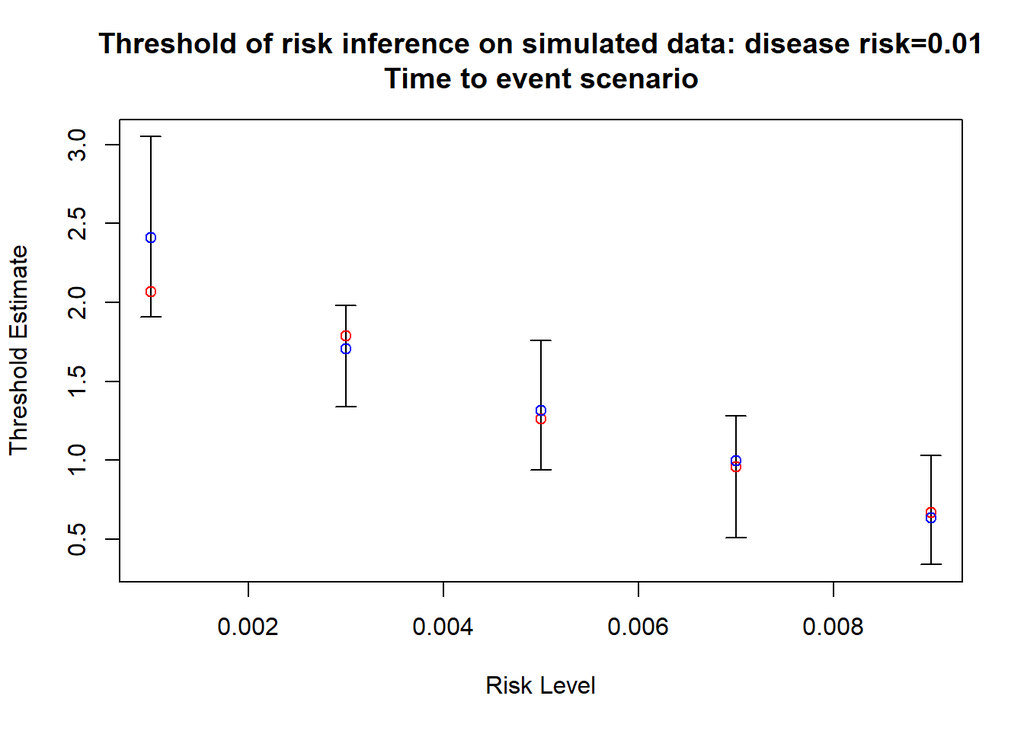

```r
adjusted_results_low <- low_risk_tte_results %>% filter(Method=="Adjusted")

# Now plot
plotCI(x=adjusted_results_low$Risk_Level, y=adjusted_results_low$Est,
       ui=adjusted_results_low$CI_UL,li=adjusted_results_low$CI_LL, xlab="Risk Level", ylab="Threshold Estimate",
       col="red",scol="black", main="Threshold of risk inference on simulated data: disease risk=0.01\nTime to event scenario")
points(x=as.numeric(names(sim_data$true_thresholds)), y=sim_data$true_thresholds, col="blue")
```

```r
## Medium risk example
sim_data <- Sim_data_logistic(Risk = 0.1, n=12500, p=c(0.009, 0.01, 0.03, 0.05, 0.07, 0.09), p0=0.2, p1=1, seed_val = 012)

vac_data_analysis_MR <- sim_data$simmed_data %>% select(S_obs, TObs, Cstatus)
med_risk_tte_results <- Thres_Surv(dataset = vac_data_analysis_MR, p=c(0.009, 0.01, 0.03, 0.05, 0.07, 0.09),
                                   weighted=TRUE, bts=2000)
med_risk_tte_results
```

```
##    Risk_Level   Method  Est CI_LL CI_UL CI_Width
## 1       0.009 Adjusted 2.94  2.75  3.08     0.33
## 2       0.010 Adjusted 2.88  2.71  3.06     0.35
## 3       0.030 Adjusted 2.14  2.02  2.26     0.24
## 4       0.050 Adjusted 1.76  1.64  1.90     0.26
## 5       0.070 Adjusted 1.41  1.28  1.53     0.25
## 6       0.090 Adjusted 1.01  0.62  1.19     0.56
## 7       0.009    Naive 2.71  2.52  2.86     0.35
## 8       0.010    Naive 2.63  2.47  2.77     0.29
## 9       0.030    Naive 1.85  1.75  1.95     0.20
## 10      0.050    Naive 1.33  1.20  1.44     0.24
## 11      0.070    Naive 0.51  0.27  0.90     0.63
## 12      0.090    Naive 0.27  0.27  0.34     0.07
```

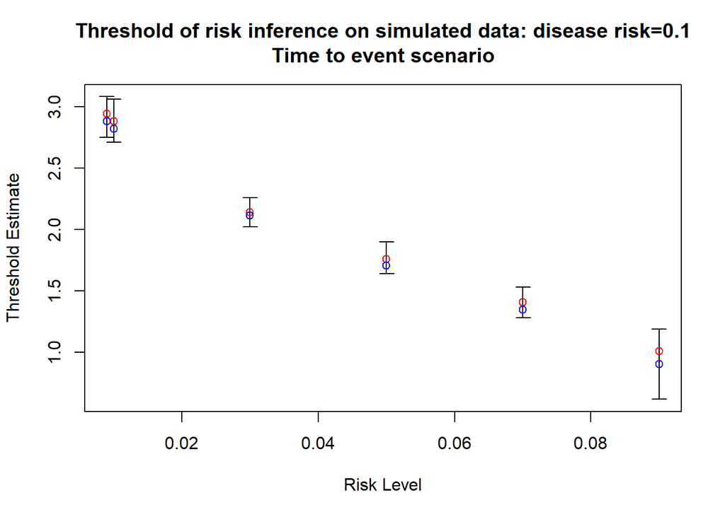

```r
adjusted_results_med <- med_risk_tte_results %>% filter(Method=="Adjusted")

# Now plot
plotCI(x=adjusted_results_med$Risk_Level, y=adjusted_results_med$Est,
       ui=adjusted_results_med$CI_UL, li=adjusted_results_med$CI_LL, xlab="Risk Level", ylab="Threshold Estimate",col="red",scol="black", main="Threshold of risk inference on simulated data: disease risk=0.1\nTime to event scenario")
points(x=as.numeric(names(sim_data$true_thresholds)), y=sim_data$true_thresholds, col="blue", sub="Time to event scenario")
```